# Итоговый проект

Группа N 14

### Предобработка

На этапе предобработки данных был проведён текстовый анализ с помощью LDA. Целью текстового анализа являлось посмотреть, как фильмы разбиты по темам. Также была получена информация, какие примерно это темы. Загрузим необходимые библиотеки и датасеты, с которыми будем работать:

```r
knitr::opts_chunk$set(echo = TRUE)
# Загрузка данных и библиотек
library(tidyverse)
library(tidyr)
library(recommenderlab)
library(dplyr)
library(ggplot2)
library(knitr)
library(LDAvis)
library(topicmodels)
library(stringr)
library (tidytext)

load("~/shared/minor2_2022/data/project/metadata_g_4.RData")
load("~/shared/minor2_2022/data/project/ratings_g_4.RData")
```

Построим таблицу, необходимую для LDA анализа. Сначала соединим датасет с названиями тегов и с отзывами на фильмы. Для каждого фильма вычислим среднюю оценку уверенности по тегам. Если средняя оценка уверенности < 3.0, то будем считать, что тег фильму не подходит.

```r
colnames(tags) = c("tag", "tag_id") #Переименовываем колонки
tags_full = left_join(survey_answers, tags) %>%
  select(-user_id)
  #Соединяем датасеты и убираем колонку с данными о пользователе


tags_full = tags_full %>%
  group_by(item_id, tag) %>%
  summarise(mean_conf = mean(score)) %>%
  filter(mean_conf > 3.0) #Берём среднее по всем уверенностям и отфильтровываем
```

Получаем таблицу с информацией, какому фильму соответствуют какие теги. Теперь можно строить модель LDA:

```r
tags_dtm <- tags_full %>%
  count(item_id, tag) %>%
  cast_dtm(item_id,tag, n)

tags_lda <- LDA(tags_dtm, k = 8, control = list(seed = 12345))
```

Попробуем примерно представить, какие темы мы получили. Получим из модели таблицу с вероятностями того, что слово относится к той или иной теме. За эту вероятность отвечает коэффициент beta.

```r
tags_topics <- tidy(tags_lda, matrix = "beta")
```

Посмотрим на самые популярные слова в каждой из тем.

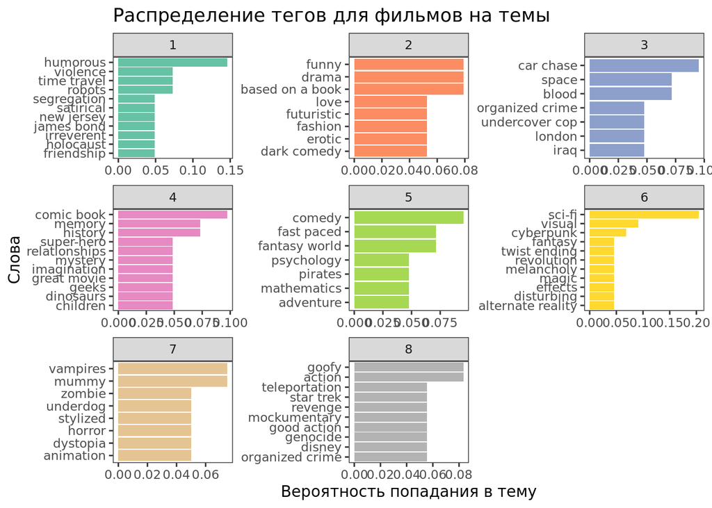

```r
tags_top_terms <- tags_topics %>%
  group_by(topic) %>%
  top_n(7, beta) %>%
  ungroup() %>%
  arrange(topic, -beta) #отбираем топ 7 слов с наибольшими вероятностями попасть в тему (слов может быть больше 7, так как некоторые вероятности совпадают)

#Строим график
tags_top_terms %>%
  mutate(term = reorder(term, beta)) %>%
  ggplot(aes(term, beta, fill = factor(topic))) +
  geom_col(show.legend = FALSE) +
  labs(title = "Распределение тегов для фильмов на темы", x = "Слова" , y = "Вероятность попадания в тему") +
  facet_wrap(~ topic, scales = "free") +
  coord_flip() +
  scale_fill_brewer(palette = "Set2") +
  theme_test() #Убираем сетку на заднем плане
```

По этим ключевым словам можно примерно догадаться, о чём каждая из выделенных тем. Теперь посмотрим на принадлежность фильма к той или иной теме. Получим из модели gamma – коэффициент, который обозначает вероятность того, что фильм относится к теме.

```r
films_topics = tidy(tags_lda, matrix = "gamma")
films_topics
```

```
## # A tibble: 1,416 × 3
##    document topic  gamma
##    <chr>    <int>  <dbl>
##  1 1            1 0.854
##  2 16           1 0.0470
##  3 21           1 0.0164
##  4 29           1 0.0470
##  5 32           1 0.234
##  6 34           1 0.0209
##  7 39           1 0.0289
##  8 47           1 0.0209
##  9 50           1 0.0134
## 10 145          1 0.0470
## # ℹ 1,406 more rows
```

Будем считать, что фильм принадлежит теме, если вероятность для него попасть в эту тему > 0.45. Получаем таблицу, в которой указано, каким темам принадлежит фильм.

```r
films_themes = films_topics %>% filter(gamma > 0.45) %>% select(-gamma) #отфильтровываем и убираем gamma
colnames(films_themes) = c("item_id", "topic")
films_themes = films_topics %>% filter(gamma > 0.45)
colnames(films_themes) = c("item_id", "topic","gamma")
films_themes$item_id = as.numeric(films_themes$item_id)
```

Получили таблицу, которая указывает, к какой теме (или темам) относится каждый фильм. Далее эта таблица была использована при построении одной из рекомендательных систем.

Также в предобработке данных для построения content-based рекомендательной системы было принято отфильтровать теги по уверенности пользователя в нем. Если уверенность низкая, то тег для фильма убирался

```r
# Фильтруем теги по уверенности пользователя в них. Оценка тега<3-убираем
colnames(tags) = c("tag", "tag_id")
tags_full = inner_join(tags, survey_answers)
tags_full = tags_full %>%
  group_by(item_id, tag) %>%
  summarise(mean_confident = mean(score)) %>%
  filter(mean_confident >= 3.0)
```

### Коллаборативная фильтрация

Будем использовать способ IBCF (Item-Based Collaborative Filtering), так как он лучше подходит для построения рекомендательной системы в данном случае по следующим причинам: учитывает сходство между фильмами, позволяет рекомендовать фильмы на основе схожих элементов. IBCF предоставляет персонализированные рекомендации, учитывая предпочтения пользователей.(В конце приведена оценка, доказывающая, что метод IBCF в данном случае оправдан)

```r
rates = pivot_wider(ratings, names_from = item_id, values_from = rating) #Преобразуем к таблице в "широком" формате, чтобы все работало с recommendlab
userNames = rates$user_id #Для дальнейшей работы в данных должны остаться только оценки, никаких дополнительных характеристик, поэтому сохраним id пользователей и удалим столбец с id пользователей
rates = select(rates, -user_id)
rates = as.matrix(rates)
rownames(rates) = userNames #добавляем конкретные айди, чтобы потом не искать
ra_movie_matrix = as(rates, "realRatingMatrix")
```

В данном случае таблица “Rating frequency” показывает, сколько раз каждое значение рейтинга встречается в наших данных (в исходной матрице рейтингов ra_movie_matrix). Это помогает нам увидеть, какие рейтинги более популярны (или непопулярны) среди пользователей. Гистограмма рейтингов представляет эти данные в виде столбцов, чтобы мы могли визуально оценить, какие значения рейтинга наиболее часто встречаются. Например, если таблица показывает, что рейтинг 4 (высокое предпочтение) имеет наибольшее количество оценок, это может указывать на то, что большинство пользователей предпочитают фильмы с высоким рейтингом - как раз, как в нашем случае.

```r
similarity_films10 <- similarity(ra_movie_matrix, method = "cosine", which = "items")
#Количество оценок, соответствующих каждому значению оценки, показано ниже
vector_ratings <- as.vector(ra_movie_matrix@data)
kable(table(vector_ratings), caption="Rating frequency")
```

Rating frequency

| vector_ratings | Freq |
| --- | --- |
| 0 | 1464101 |
| 0.5 | 480 |
| 1 | 860 |
| 1.5 | 670 |
| 2 | 2293 |
| 2.5 | 2185 |
| 3 | 6546 |
| 3.5 | 5544 |
| 4 | 9606 |
| 4.5 | 3666 |
| 5 | 4049 |

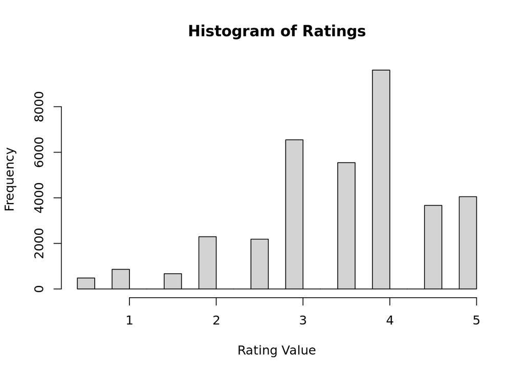

```r
vector_ratings = vector_ratings[vector_ratings != 0] #Поскольку рейтинг со значением 0 означает отсутствие рейтинга, мы удаляем такие рейтинги из вектора рейтингов
hist(vector_ratings, main="Histogram of Ratings", xlab="Rating Value") #Выше мы видим, что рейтинг 4 (указывающий на высокое предпочтение) является наиболее распространенным рейтингом, и что значения рейтинга смещены влево.
```

Для построения модели коллаборативной фильтрации мы можем ограничить входные данные на основе минимальных порогов. Здесь мы ограничиваем обучение модели теми пользователями, которые оценили не менее 10 фильмов, и теми фильмами, которые оценили не менее 35 пользователей.

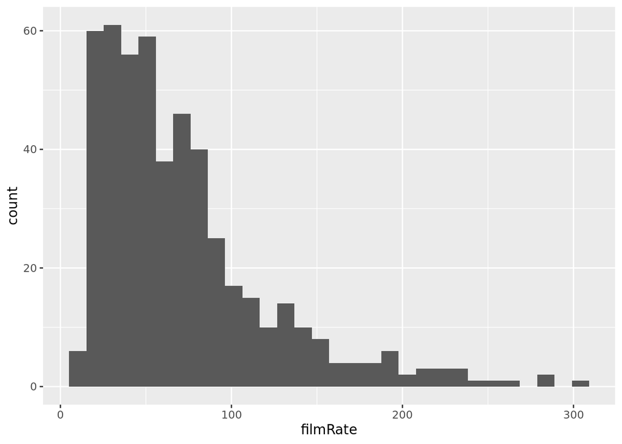

```r
ggplot(data = data.frame(filmRate=colCounts(ra_movie_matrix))) + geom_histogram(aes(x=filmRate))
```

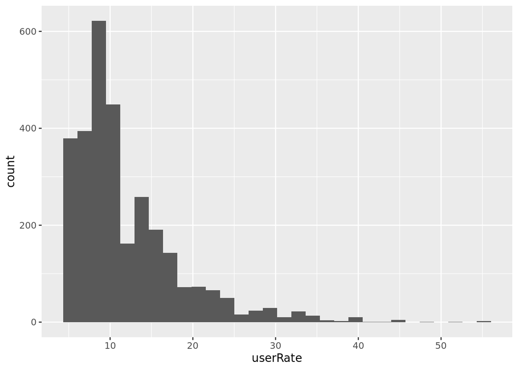

```r
ggplot(data = data.frame(userRate=rowCounts(ra_movie_matrix))) + geom_histogram(aes(x=userRate))
```

```r
ratings_new = ra_movie_matrix[rowCounts(ra_movie_matrix) > 10, colCounts(ra_movie_matrix) > 35] #подбор значений исходя из графиков, построенных выше
```

Разделим данные на тестовую и обучающую выборки. На обучающей построим модель, т.е. зададим общие принципы рекомендации, для пользователей из тестовой будем рекомендовать фильмы. Для правильной оценки разделим данные на тестовую и обучающую выборки.

Для работы функции пользователю необходимо знать свой ID. Тогда он получит рекомендацию из 6 фильмов. Если пользоватеть новый, ему будет предложена рекомендация из 10 наиболее популярных фильмов. В следующем чанке представлена функция для CF

```r
recc_model = Recommender(data = ratings_new, method = "IBCF") #предварительное построение модели
cf_recommendation = function(user_id) {
  recc_predicted = predict(object = recc_model, newdata = ratings_new, n = 6)

  names(recc_predicted@items) = rownames(ratings_new)
  recc_user_1 = recc_predicted@items[[user_id]]
  movies_user_1 = recc_predicted@itemLabels[recc_user_1]
  names_movies_user_1 = metadata$title[match(movies_user_1, metadata$item_id)]

  if (length(names_movies_user_1)==0L) {
  new_var=metadata %>% select(item_id,title) %>% left_join(ratings) %>% select(-item_id,-user_id) %>%       group_by(title,rating) %>% count(rating) %>% ungroup()
  good_rating=new_var %>% filter(rating>=3.5) %>%  select(-rating) %>%  group_by(title) %>% summarise(sum_good=sum(n))
  bad_rating=new_var %>% filter(rating<3.5) %>%  select(-rating) %>%  group_by(title) %>% summarise(sum_bad=sum(n))
  new_rating = good_rating %>% left_join(bad_rating)
  new_rating=new_rating %>% mutate(absolute_value=(sum_good-sum_bad)/(sum_good+sum_bad)) %>% arrange(-absolute_value)
  answer=new_rating[1:10,] %>% select(title)
  answer
  } else {
    names_movies_user_1
  }
}
```

**Оценивание рекомендации:** для IBCF метода:

```r
model_IBCF = Recommender(data = getData(sets, "train"), method = "IBCF")
predicted_IBCF = predict(object = model_IBCF, newdata = getData(sets, "known"), type = "ratings")

accuracy_IBCF = calcPredictionAccuracy(x = predicted_IBCF,
                                        data = getData(sets, "unknown"),
                                        byUser = F)
accuracy_IBCF
```

```
##      RMSE       MSE       MAE
## 0.9008374 0.8115080 0.7142857
```

для метода UBCF:

```r
model_UBCF = Recommender(data = getData(sets, "train"), method = "UBCF", parameter = list(nn = 6))
predicted_UBCF = predict(object = model_UBCF, newdata = getData(sets, "known"), type = "ratings")

accuracy_UBCF = calcPredictionAccuracy(x = predicted_UBCF,
                                         data = getData(sets, "unknown"),
                                         byUser = F)
accuracy_UBCF
```

```
##      RMSE       MSE       MAE
## 1.0133890 1.0269573 0.7839683
```

Действительно, в методе IBCF показатель MAE и другие ниже, то есть рекомендации качественнее. Мы сделали верный выбор.

### Content-based рекомендация

Использовались переменные: item_id, title (выводились названия фильмов), tag, score(в предобработке). Также была добавлена переменная, которая считала для каждого фильма средний рейтинг по пользователю. Также стоит уточнить, что в связи с отсечением определенных тегов, кол-во фильмов сильно сократилось.

```r
# Считаю среднюю оценку фильмов по пользователю (avgRating-это рейтинг не пользователей, а MovieLens)
average_value=ratings %>% group_by(item_id) %>% summarize(rating = mean(rating, na.rm = T))
```

Создаю копию metadata

```r
metadata1=metadata %>% select(item_id)
```

Объединяю и преобразовываю таблицу так, чтобы в столбцах были теги (1-тег для фильма есть, 0-отсутствует)

```r
merged_data = inner_join(metadata1, tags_full, by = "item_id")  %>% select(-mean_confident)
merged_data=inner_join(merged_data, average_value) %>% mutate(tags_v=1)
merged_data=merged_data %>% pivot_wider(names_from = "tag", values_from = "tags_v", values_fill=0)
```

Смотрим схожесть

```r
rownames=merged_data$item_id
merged_data = merged_data %>% dplyr::select(-item_id)
rownames(merged_data) = rownames
sim = lsa::cosine(t(as.matrix(merged_data)))
diag(sim) = 0
```

Код с функцией для СВ:

```r
recommendations = function(id){
  user = ratings %>% filter(user_id == id & rating == 5)
  if (nrow(user)==0) {
    new_var=metadata %>% select(item_id,title) %>% left_join(ratings) %>% select(-item_id,-user_id) %>%       group_by(title,rating) %>% count(rating) %>% ungroup()
  good_rating=new_var %>% filter(rating>=3.5) %>%  select(-rating) %>%  group_by(title) %>% summarise(sum_good=sum(n))
  bad_rating=new_var %>% filter(rating<3.5) %>%  select(-rating) %>%  group_by(title) %>% summarise(sum_bad=sum(n))
  new_rating = good_rating %>% left_join(bad_rating)
  new_rating=new_rating %>% mutate(absolute_value=(sum_good-sum_bad)/(sum_good+sum_bad)) %>% arrange(-absolute_value)
  answer=new_rating[1:5,] %>% select(title)
  answer
} else {
  ifelse(test = nrow(user) == 0, (user = ratings %>% filter(user_id == id & rating == 4)),       user)
    mostSimilar = head(sort(sim[,as.character(user$item_id)], decreasing = T), n = 5)
    a = which(sim[,as.character(user$item_id)] %in% mostSimilar, arr.ind = TRUE)
    index = arrayInd(a, .dim = dim(sim[,as.character(user$item_id)]))
    result = rownames(sim)[index[,1]]
    recommend = filter(metadata,item_id %in% result) %>% dplyr::select(title)

  recommend
}
}
```

**Оценивание рекомендации:** Оценивание результатов проводилось тестированием функции для различных пользователей

### Примеры

##### Примеры collaborative filtering

Для коллаборативной фильтрации не было предложено сценариев, поэтому мы привели пример и оценку системы для рандомно выбранного пользователя.

```r
films_by_tags = inner_join(tags_full, metadata) %>%
  select(c("tag", "mean_confident", "title", "avgRating"))

#посмотрим на среднюю оценку пользователей и объединим с датасетом
films_by_rating = ratings%>% group_by(user_id)
films_full = films_by_tags %>% inner_join(films_by_rating)
#Посмотрим, какие фильмы оценил пользователь на оценку выше 3
random_id = films_full %>% filter(user_id == "280" & rating > 3)
knitr::kable(random_id %>% select(tag, title, avgRating, rating))
```

| item_id | tag | title | avgRating | rating |
| --- | --- | --- | --- | --- |
| 2858 | depressing | American Beauty (1999) | 4.10904 | 4.5 |
| 2858 | depression | American Beauty (1999) | 4.10904 | 4.5 |
| 2858 | drugs | American Beauty (1999) | 4.10904 | 4.5 |
| 2858 | entertaining | American Beauty (1999) | 4.10904 | 4.5 |
| 2858 | philosophy | American Beauty (1999) | 4.10904 | 4.5 |
| 2858 | poignant | American Beauty (1999) | 4.10904 | 4.5 |
| 2858 | quirky | American Beauty (1999) | 4.10904 | 4.5 |
| 7438 | ennio morricone | Kill Bill: Vol. 2 (2004) | 3.82295 | 4.5 |
| 7438 | goofy | Kill Bill: Vol. 2 (2004) | 3.82295 | 4.5 |
| 7438 | multiple storylines | Kill Bill: Vol. 2 (2004) | 3.82295 | 4.5 |
| 7438 | organized crime | Kill Bill: Vol. 2 (2004) | 3.82295 | 4.5 |
| 7438 | revenge | Kill Bill: Vol. 2 (2004) | 3.82295 | 4.5 |
| 7438 | samurai | Kill Bill: Vol. 2 (2004) | 3.82295 | 4.5 |

```r
#вывод: По полученным оценкам пользователю необходимо рекомендовать фильмы со средним рейтингом на MovieLens (от 3.7 до 4.5). Судя по тегам, пользователю нравятся фильмы про преступления, месть, философию и фильмы, отмеченные тегом депрессивный. Теперь оценим фильмы, которые порекомендует данному пользовтелю получившаяся рекомендательная система.

cf_recommendation(280)
```

```
## [1] "Zombieland (2009)"           "Kalifornia (1993)"
## [3] "Jurassic Park (1993)"        "Toy Story (1995)"
## [5] "Seven (a.k.a. Se7en) (1995)" "Memento (2000)"
```

```r
#посмотрим характеристики данных фильмов
avRating = ratings %>% group_by(item_id) %>% summarise(mean_rating = mean(rating))
avRating_films =films_full %>% inner_join(avRating)
rec_random = avRating_films %>% filter(title == c("Zombieland (2009)", "Kalifornia (1993)", "Jurassic Park (1993)", "Toy Story (1995)", "Seven (a.k.a. Se7en) (1995)","Memento (2000)"))
rec_random = rec_random %>% inner_join(films_full)
rec_random = rec_random %>% group_by(tag,title, avgRating, mean_rating ) %>% summarise(n = n())
knitr::kable(rec_random%>% select(tag, title, avgRating, mean_rating))
```

| tag | title | avgRating | mean_rating |
| --- | --- | --- | --- |
| bad science | Jurassic Park (1993) | 3.67980 | 3.649648 |
| black and white | Memento (2000) | 4.14890 | 4.182266 |
| brutal | Seven (a.k.a. Se7en) (1995) | 4.08292 | 4.048117 |
| children | Jurassic Park (1993) | 3.67980 | 3.649648 |
| classic | Toy Story (1995) | 3.89146 | 3.936567 |
| crime | Memento (2000) | 4.14890 | 4.182266 |
| dark comedy | Memento (2000) | 4.14890 | 4.182266 |
| detective | Seven (a.k.a. Se7en) (1995) | 4.08292 | 4.048117 |
| dinosaurs | Jurassic Park (1993) | 3.67980 | 3.649648 |
| humorous | Toy Story (1995) | 3.89146 | 3.936567 |
| imagination | Memento (2000) | 4.14890 | 4.182266 |
| memory | Memento (2000) | 4.14890 | 4.182266 |
| mystery | Memento (2000) | 4.14890 | 4.182266 |
| overrated | Seven (a.k.a. Se7en) (1995) | 4.08292 | 4.048117 |
| pixar animation | Toy Story (1995) | 3.89146 | 3.936567 |
| psychology | Seven (a.k.a. Se7en) (1995) | 4.08292 | 4.048117 |
| sci-fi | Jurassic Park (1993) | 3.67980 | 3.649648 |

```r
#Про полученные фильмы можно сказать, что их средняя оценка на MovieLens и средняя пользовательская оценка средняя, то есть от 3.7 до 4.5. По тегам можно увидеть, что там есть психология, преступления, жестокость и черная комедия. В данном случае по тегам не совпадают фильмы "Toy Story (1995)" и "  Jurassic Park (1993)", однако они подходят по средней оценке. Можно сказать, что из 6 фильмов 4 близки к предпочтениям пользователя.
```

##### Примеры content-based

Если пользователю понравились фильмы с тегами “entertaining”, ‘children’ и ‘classic’, то какой фильм будет порекомендован?

```r
films_by_tags = inner_join(tags_full, metadata) %>%
  select(c("tag", "mean_confident", "title", "avgRating"))

#посмотрим на среднюю оценку пользователей и объединим с датасетом
films_by_rating = ratings%>% group_by(user_id)
films_full = films_by_tags %>% inner_join(films_by_rating)
seventh = films_full %>% group_by(tag) %>% filter(tag == "classic" | tag == "children" | tag == "entertaining") #отбираем только фильмы с этими тегами
seventh %>% group_by(user_id) %>% summarise(n = n()) %>% arrange(-n) #выбираем пользователя, который поставил как можно больше оценок с такими тегами
```

```
## # A tibble: 987 × 2
##    user_id     n
##      <dbl> <int>
##  1     446     3
##  2  171203     3
##  3  205467     3
##  4  208360     3
##  5  367554     3
##  6  374747     3
##  7  533434     3
##  8  632819     3
##  9  749424     3
## 10  842984     3
## # ℹ 977 more rows
```

```r
recommendations(171203)
```

```
##                                                 title
## 1                               Monsters, Inc. (2001)
## 2                            Jurassic Park III (2001)
## 3 Men in Black II (a.k.a. MIIB) (a.k.a. MIB 2) (2002)
## 4                              Mission to Mars (2000)
## 5                            Time Machine, The (2002)
```

```r
avRating = ratings %>% group_by(item_id) %>% summarise(mean_rating = mean(rating))
avRating_films =films_full %>% inner_join(avRating)
rec_random = avRating_films %>% filter(title == c("Monsters, Inc. (2001)", "Jurassic Park III (2001)", "Men in Black II (a.k.a. MIIB) (a.k.a. MIB 2) (2002)", "Mission to Mars (2000)", "Time Machine, The (2002)"))
rec_random = rec_random %>% inner_join(films_full)
rec_random = rec_random %>% group_by(tag,title, avgRating, mean_rating ) %>% summarise(n = n())
knitr::kable(rec_random%>% select(tag, title, avgRating, mean_rating))
```

| tag | title | avgRating | mean_rating |
| --- | --- | --- | --- |
| adventure | Monsters, Inc. (2001) | 3.84357 | 3.785377 |
| bad science | Mission to Mars (2000) | 2.68748 | 2.465909 |
| children | Monsters, Inc. (2001) | 3.84357 | 3.785377 |
| dinosaurs | Jurassic Park III (2001) | 2.72549 | 2.529851 |
| sci-fi | Men in Black II (a.k.a. MIIB) (a.k.a. MIB 2) (2002) | 3.02348 | 2.913934 |
| sci-fi | Time Machine, The (2002) | 2.88508 | 2.677778 |

**Вывод**: по тегам один из предложенных фильмов был с тегом “children”, что совпадает с запросом пользователя. однако, посмотрев описание всех предложенных фильмов, можно сказать, что предложены соответствующие вкусам пользователя фильмы.

### Выводы

Для ответов на большинство вопросов из peer_review следует создать новые рекомендательные системы, где будут вводиться топики из LDA или имена режиссеров. Однако, пока что возникли трудности с написанием функции. На остальные замечания мы смогли ответить и смогли исправить многие недочеты.

### Ответы на вопросы peer review

**Вопрос:** Не совсем понятно из презентации, как используется метод коллаборативной фильтрации для рекомендации рандомного пользования, в целом, код логичный, но как раз, как не имея никакой информации о человеке и не запрашивая её можно использовать

*Ответ:* Без информации о пользователе или его предпочтениях нет способа определить, каких пользователей считать похожими или какие элементы рекомендовать. Поэтому, без какой-либо информации, коллаборативная фильтрация не может быть применена эффективно. Для нового пользователя рекомендуется топ из 10 фильмов с высокими оценками.

**Вопрос:** Непонятно, как используется сетевой анализ и используется ли вообще.

*Ответ:* Нет, сетевой анализ не используется. В своей работе мы ограничились текстовым анализом.

**Вопрос:** Я так и не поняла, что принимает на вход функция с content-based рекомендательной системы?

*Ответ:* Вводится id пользователя

**Вопрос:** Можно добавить оценку, где показывается, что IBCF лучше чем UBCF(даже используя MSE, MAE).

*Ответ:* Оценка была проведена. Действительно, IBCF рекомендации лучше, так как показатели MSE, MAE, RMSE ниже, чем для UBCF.